# Git 101

#### GIT BASICS

If you have never used Git before, here is a high level understanding of how it works.

This reference will focus on git in the command line. You can work with git without the use of Git Command Lind (Git CLI), but similar to working with your terminal vs. your Operating system’s UI, you will find more flexibility in what you can do, and see that you have more control over your workspace. If you choose to forgo the CLI, Visual Studios has extensions you can use to commit and push your changes to the remote repo.

Online documentation can be needlessly complex.:

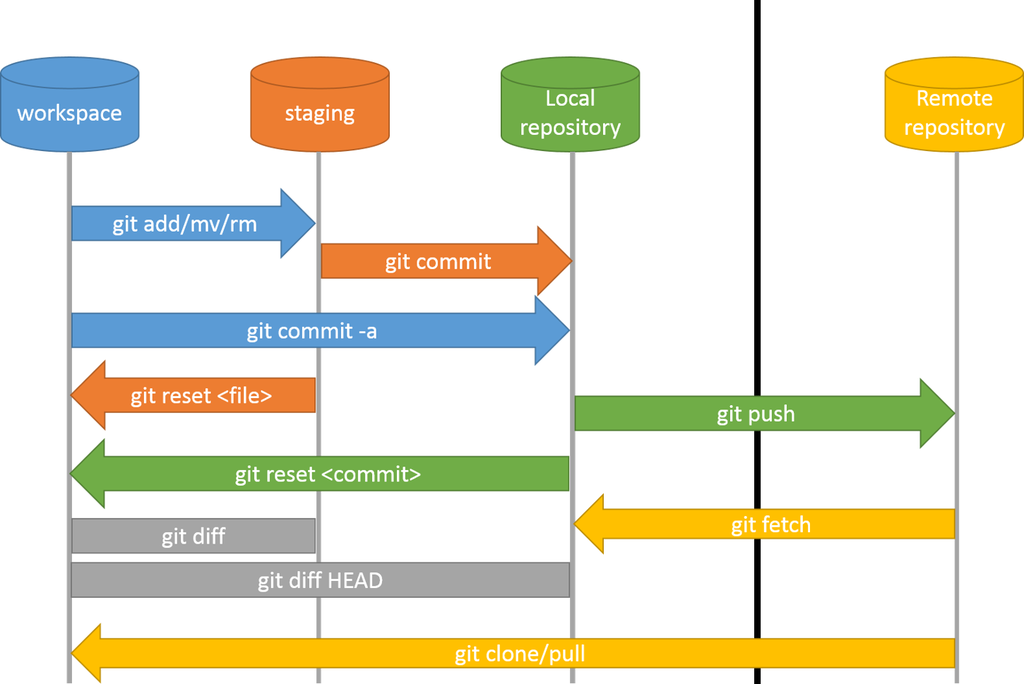

So if this makes no sense, that’s okay! I have created what I would call a similar, but simplified visual with the steps detailed at the bottom.

There are just a few key things to note:

- *Remote/Origin* in our use case is the github repository
- *Staging* is not a real place, but rather a state that your files can be in. Do we want git to see the files? If so, we need to stage them using `git add`. Why is this valuable? More [here](https://stackoverflow.com/questions/49228209/whats-the-use-of-the-staging-area-in-git)

Hopefully everything else is pretty straightforward.

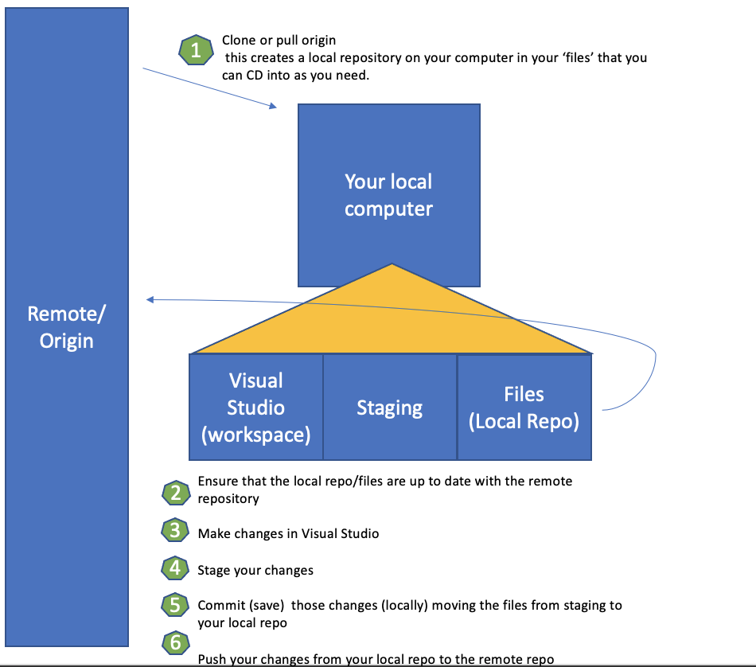

#### BRANCHING TECHNIQUE FOR THIS SEMESTER

To keep the repository clean, prevent accidental overwrites, and unnecessary complexity, we will create a branch from master for each snippet of code we create. After that branch is commited, pushed, and reviewed by a teammate, this code will be merged into the master branch, and will rinse and repeat this process. This is a simple process and can be done in the command line as outlined below.

[figure not shown]

#### INSTALLING GIT FOR WINDOWS AND MAC OS

https://git-scm.com/book/en/v2/Getting-Started-Installing-Git

#### USING GIT IN THE COMMAND LINE

1. `Git clone <your_SSH.link>` **for a new repo**

   OR

   `Git pull origin` **If you already have a local copy to update your files**
2. `cd <repofolder>` **to go into the folder where your code is stored. ex: on my local computer, I have a folder titled “plansolver” that contains my local files similar to the remote repo so I would `cd plansolver`**
3. Make sure you are in the master branch **you should see username ~folder (master) ] ex: astallwo@astallwo-MOBL MINGW64 ~/plansolver (master)**
4. `git checkout master` **if you are not in the master branch to exit your current branch. we want to make sure we are not creating a branch in a branch, but rather branching from master**
5. `git branch <branchname>` **to create a new branch called branchname**
6. Make edits through Visual Studio + save those edits to your local repo
7. `git add .` **to stage your changes**
8. `git status` **to make sure the changes github has captured align with the changes you made**
9. `git commit -m "your message here"` **to ‘save’ your changes**
10. `git push -o merge_request.create origin <yourBranchName>` **to push changes and make a new merge request**

#### HELPFUL LINKS

[Git documentation](https://git-scm.com/doc)

[Why we stage](https://stackoverflow.com/questions/49228209/whats-the-use-of-the-staging-area-in-git)